[output not shown]

```r
# Business Forecasting HW5
# Name - Vaibhav Rajesh Vesmaker
# Email - vaibhav.vesmaker@rutgers.edu



library(fpp)
# Load the necessary libraries for forecasting
library(fpp2)
# Load the Boston dataset
data(boston) # picking up the boston dataset
boston
```

```
##            nyase   bse
## Jan 1967 10581.6  78.8
## Feb 1967 10234.3  69.1
## Mar 1967 13299.5  87.6
## Apr 1967 10746.5  72.8
## May 1967 13310.7  79.4
## Jun 1967 12835.5  85.6
## Jul 1967 12194.2  75.0
## Aug 1967 12860.4  85.3
## Sep 1967 11955.6  86.9
## Oct 1967 13351.5 107.8
## Nov 1967 13285.9 128.7
## Dec 1967 13784.4 134.5
## Jan 1968 16336.7 148.7
## Feb 1968 11040.5  94.2
## Mar 1968 11525.3 128.1
## Apr 1968 16056.4 154.1
## May 1968 18464.3 191.3
## Jun 1968 17092.2 191.9
## Jul 1968 15178.8 159.6
## Aug 1968 12774.8 185.5
## Sep 1968 12377.8 178.0
## Oct 1968 16856.3 271.8
## Nov 1968 14635.3 212.3
## Dec 1968 17436.9 139.4
## Jan 1969 16482.2 106.0
## Feb 1969 13905.4 112.1
## Mar 1969 11973.7 103.5
## Apr 1969 12573.6  92.5
## May 1969 16566.8 116.9
## Jun 1969 13558.7  78.9
## Jul 1969 11530.9  57.4
## Aug 1969 11278.0  75.9
## Sep 1969 11263.7 109.8
## Oct 1969 15649.5 129.2
## Nov 1969 12197.1 115.1
```

```r
# Print the first few rows of the Boston dataset
head(boston)
```

```
##            nyase  bse
## Jan 1967 10581.6 78.8
## Feb 1967 10234.3 69.1
## Mar 1967 13299.5 87.6
## Apr 1967 10746.5 72.8
## May 1967 13310.7 79.4
## Jun 1967 12835.5 85.6
```

```r
# Check the class of the Boston dataset
class(boston)
```

```
## [1] "mts" "ts"
```

```r
# Identify the frequency (seasonality) of the time series
frequency(boston) # The cycle of this time series is 12 months in a year
```

```
## [1] 12
```

```r
# Generate a summary of the Boston dataset
summary(boston)
```

```
##      nyase            bse
##  Min.   :10234   Min.   : 57.40
##  1st Qu.:11965   1st Qu.: 85.45
##  Median :13286   Median :109.80
##  Mean   :13577   Mean   :121.25
##  3rd Qu.:15414   3rd Qu.:144.05
##  Max.   :18464   Max.   :271.80
```

```r
# Check the dimensions of the dataset (number of rows and columns)
dim(boston) # [1] 35  2   i.e 35 rows and 2 columns
```

```
## [1] 35  2
```

```r
# List the column names of the dataset
colnames(boston)  # [1] "nyase" "bse"
```

```
## [1] "nyase" "bse"
```

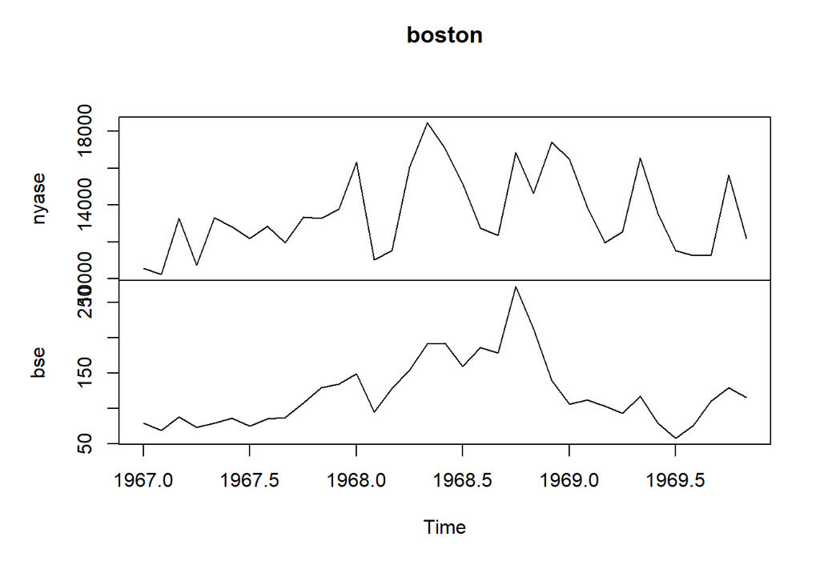

```r
# Plot the Boston time series data
plot(boston)
```

```r
# Check the number of rows in the dataset
nrow(boston) # 35 rows
```

```
## [1] 35
```

```r
# Check the number of columns in the dataset
ncol(boston) # 2 columns
```

```
## [1] 2
```

```r
# Create a time series object for the "bse" column
bse_ts <- ts((boston[,"bse"]), frequency = 12, start = c(1967,1))
bse_ts
```

```
##        Jan   Feb   Mar   Apr   May   Jun   Jul   Aug   Sep   Oct   Nov   Dec
## 1967  78.8  69.1  87.6  72.8  79.4  85.6  75.0  85.3  86.9 107.8 128.7 134.5
## 1968 148.7  94.2 128.1 154.1 191.3 191.9 159.6 185.5 178.0 271.8 212.3 139.4
## 1969 106.0 112.1 103.5  92.5 116.9  78.9  57.4  75.9 109.8 129.2 115.1
```

```r
# Check the class of the time series
class(bse_ts)
```

```
## [1] "ts"
```

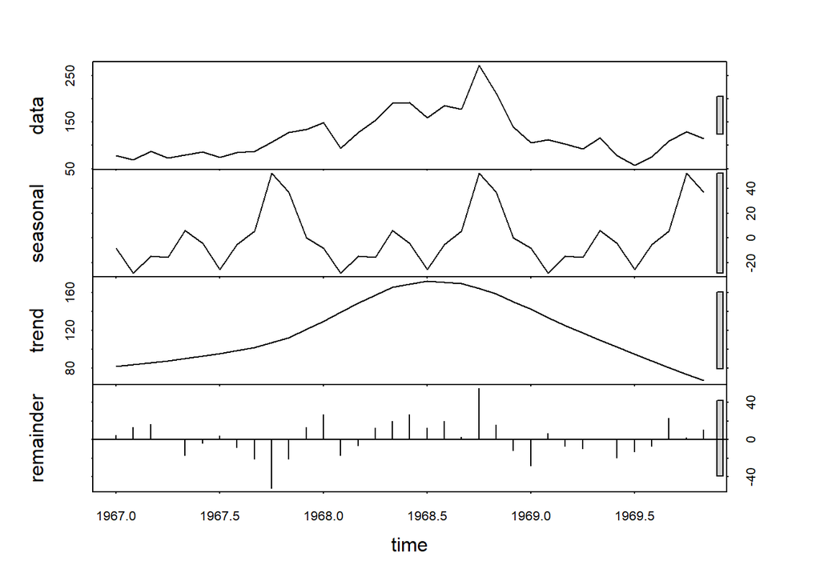

```r
# Perform seasonal decomposition using STL
stl_decomp <- stl(bse_ts, s.window ="periodic")
# Plot the decomposed components
plot(stl_decomp)  # we can see that from 1967 to mid 1968, there is a positive trend and after that there is a negative trend...
```

```r
# Print attributes of the decomposition
attributes(stl_decomp)
```

```
## $names
## [1] "time.series" "weights"     "call"        "win"         "deg"
## [6] "jump"        "inner"       "outer"
##
## $class
## [1] "stl"
```

```r
# Extract the seasonally adjusted data
# Lets print out a seasonal adjustment
seasadj(stl_decomp) # Returns seasonally adjusted data constructed by removing the seasonal component.
```

```
##            Jan       Feb       Mar       Apr       May       Jun       Jul
## 1967  86.88885  97.42769 102.19983  88.46999  73.47349  89.76223 100.31764
## 1968 156.78885 122.52769 142.69983 169.76999 185.37349 196.06223 184.91764
## 1969 114.08885 140.42769 118.09983 108.16999 110.97349  83.06223  82.71764
##            Aug       Sep       Oct       Nov       Dec
## 1967  90.63613  81.15462  55.23835  91.58879 134.34235
## 1968 190.83613 172.25462 219.23835 175.18879 139.24235
## 1969  81.23613 104.05462  76.63835  77.98879
```

```r
boston[,"bse"] # this is bse column to refer the original values
```

```
##        Jan   Feb   Mar   Apr   May   Jun   Jul   Aug   Sep   Oct   Nov   Dec
## 1967  78.8  69.1  87.6  72.8  79.4  85.6  75.0  85.3  86.9 107.8 128.7 134.5
## 1968 148.7  94.2 128.1 154.1 191.3 191.9 159.6 185.5 178.0 271.8 212.3 139.4
## 1969 106.0 112.1 103.5  92.5 116.9  78.9  57.4  75.9 109.8 129.2 115.1
```

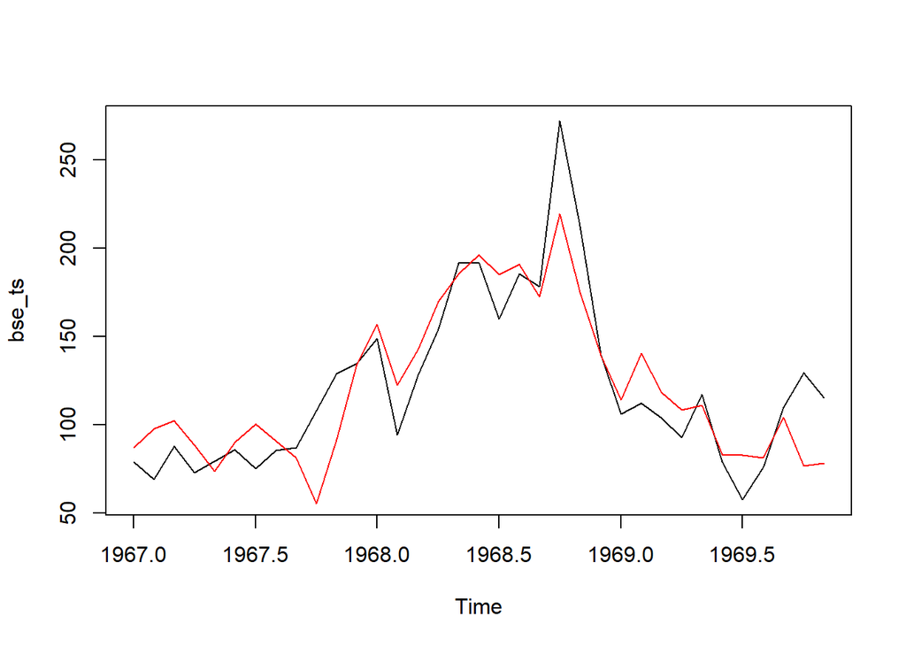

```r
# Overlay the original time series and seasonally adjusted data
# Plot a line on the graph
plot(bse_ts)
lines(seasadj(stl_decomp), col="Red")
```

```r
# Default period forecast
f_stl <- forecast(stl_decomp)
# Generate forecasts using the default number of periods (h = 15)
# you can pass the # of period
f_stl <- forecast(stl_decomp,h=15)
f_stl
```

```
##          Point Forecast         Lo 80     Hi 80       Lo 95    Hi 95
## Dec 1969       78.19622  48.297924519 108.09451   32.470724 123.9217
## Jan 1970       69.94972  29.275261033 110.62418    7.743503 132.1559
## Feb 1970       49.71088   0.569092432  98.85267  -25.444999 124.8668
## Mar 1970       63.43874   7.087880753 119.78959  -22.742461 149.6199
## Apr 1970       62.36858  -0.368353062 125.10551  -33.579279 158.3164
## May 1970       83.96508  15.434604329 152.49556  -20.843239 188.7734
## Jun 1970       73.87634   0.005305965 147.74738  -39.099659 186.8523
## Jul 1970       52.72093 -26.129780848 131.57163  -67.870823 173.3127
## Aug 1970       72.70244 -10.831606910 156.23649  -55.051862 200.4567
## Sep 1970       83.78395  -4.184462577 171.75236  -50.752126 218.3200
## Oct 1970      130.60022  38.410498560 222.78994  -10.391793 271.5922
## Nov 1970      115.14978  18.923748616 211.37581  -32.015234 262.3148
## Dec 1970       78.19622 -21.903493592 178.29593  -74.893080 231.2855
## Jan 1971       69.94972 -33.879254169 173.77870  -88.842993 228.7424
## Feb 1971       49.71088 -57.717978056 157.13974 -114.587381 214.0091
```

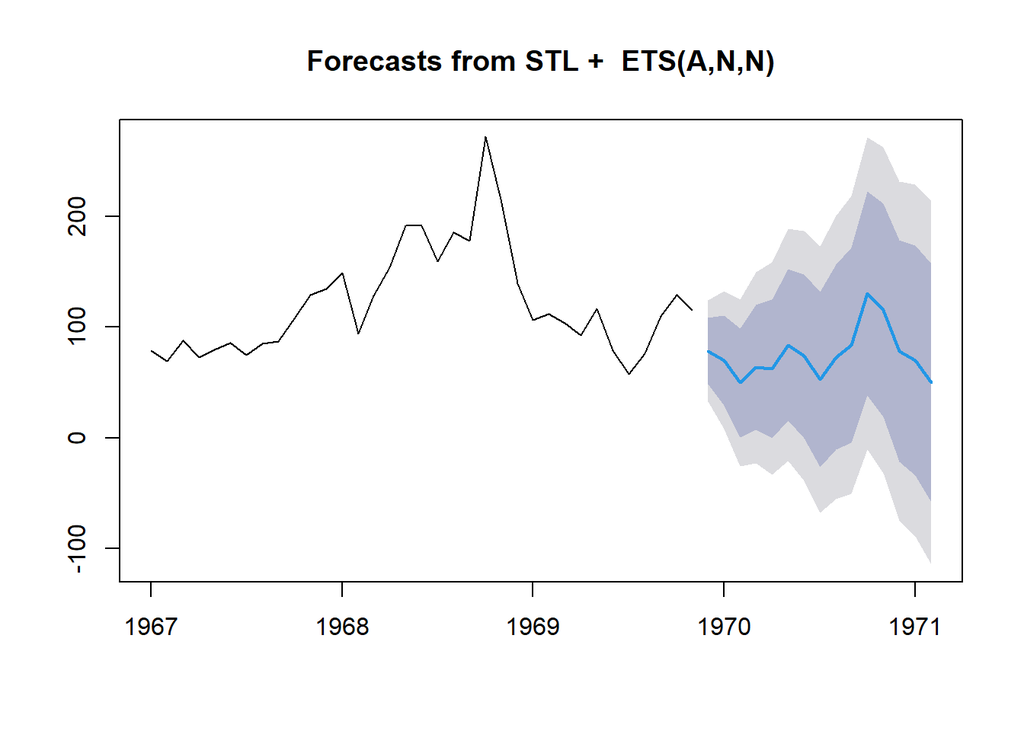

```r
# Plot the forecasts
plot(f_stl)
```

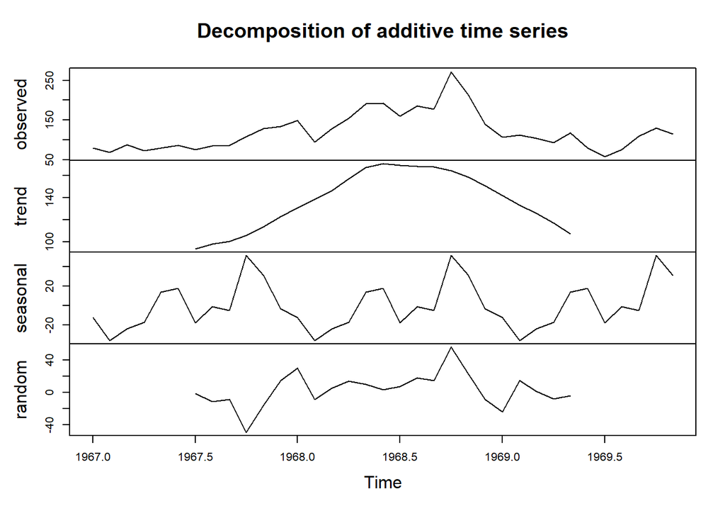

```r
# Alternative method for decomposition using decompose

decomp_bse_ts <- decompose(bse_ts)
plot(decomp_bse_ts)
```

```r
# Each one shows different attributes
attributes(decomp_bse_ts)
```

```
## $names
## [1] "x"        "seasonal" "trend"    "random"   "figure"   "type"
##
## $class
## [1] "decomposed.ts"
```

```r
# Extract seasonally adjusted data using decompose
seasadj(decomp_bse_ts)
```

```
##            Jan       Feb       Mar       Apr       May       Jun       Jul
## 1967  90.93872 104.87622 111.00747  89.63038  65.59288  67.80122  92.43038
## 1968 160.83872 129.97622 151.50747 170.93038 177.49288 174.10122 177.03038
## 1969 118.13872 147.87622 126.90747 109.33038 103.09288  61.10122  74.83038
##            Aug       Sep       Oct       Nov       Dec
## 1967  86.09288  91.86997  56.16163  97.55330 137.54497
## 1968 186.29288 182.96997 220.16163 181.15330 142.44497
## 1969  76.69288 114.76997  77.56163  83.95330
```

**The code begins by loading necessary libraries, particularly the ‘fpp’ and ‘fpp2’ libraries for business forecasting. The Boston dataset is also loaded for further analysis.**

**The dataset’s properties are explored to better understand its structure. This includes checking its dimensions (number of rows and columns), extracting the column names (which are “nyase” and “bse”), and determining the class of the dataset, which helps identify it as a time series.**

**The code identifies the dataset’s seasonality, revealing that it follows a 12-month cycle, which is common for many time series datasets. This information is crucial for time series analysis and forecasting.**

**Seasonal decomposition is performed using STL (Seasonal and Trend decomposition using Loess). This method helps break down the time series data into its individual components: seasonality, trend, and remainder (or residuals). The decomposition provides valuable insights into the underlying patterns in the data.**

**After performing the decomposition, the code extracts the seasonally adjusted data, which represents the time series with the seasonal component removed. This adjusted data is then overlaid with the original time series to visualize the impact of the seasonal component on the data.**

**The code proceeds to generate forecasts for the time series data. It uses an alternative method to decompose the time series data with the ‘decompose’ function. This provides an alternative view of the time series decomposition.**

**In summary, the code loads libraries, explores the dataset, identifies seasonality, performs seasonal decomposition using STL, extracts seasonally adjusted data, generates forecasts, and provides an alternative decomposition method for comparison. The code is a fundamental step in time series analysis, offering insights into the seasonality and trend components, which are crucial for forecasting in business contexts.**